# Predicting Success of College Football Coaching Hires

A Regression-Based Decision Framework

4-Student Team, BSDS

2026-10-28

# Executive Summary

This project fits a regression-based decision framework to 84 college-football head-coaching hires (1999–2025), testing H1–H4 in a pre-specified confirmatory model and evaluating a separate BIC-selected predictive model under honest out-of-sample validation. The four findings below are ordered by syllabus topic: model selection, diagnostics, prediction accuracy, then confirmatory inference.

**Model selection.** The BIC procedure retains a parsimonious two-predictor model (`PreviousOC + team_sp_recent`). Its adjusted R-squared (0.133) exceeds that of the 16-parameter confirmatory model (0.081), and its 10-fold CV-R-squared (0.071) is the highest of any model tested. The full table is in §5.1b.

**Diagnostics.** The main-effects residual model shows no pattern in fitted-versus-residual plots, no significant heteroscedasticity (White p = 0.833), no residual autocorrelation in a cross-sectional dataset, and no need for response transformation (Box-Cox λ̂ = 0.909, 95% CI including 1.0). WLS and OLS coefficient signs agree. See §5.0.

**Decision rule.** The Coach Hire Score is presented as an **exploratory ranking instrument**, not a classifier. Every worked example returns Inconclusive at 95% PI (interval widths ≈ 32 CPI points). §6 validates the score as exploratory only; it is not ready for operational hiring decisions.

# 1. Motivation

College-football head-coaching hires are high-stakes decisions – buyouts routinely exceed twenty million dollars – but rarely evaluated with a transparent statistical framework. A regression-based approach cannot capture every determinant (culture, fit, in-season luck) but it can identify which observable pre-hire signals consistently predict on-field success, and provide a principled ranking instrument for athletic directors.

# 2. Research Questions & Hypotheses

**RQ:** How well do observable pre-hire characteristics predict the Coach Performance Index (CPI = `sp_rel_team`) of a college-football head-coaching hire?

| Hypothesis | Predictor | Expected sign |
| --- | --- | --- |
| **H1** | Prior head-coaching win percentage (`AllPriorWinPct`) | positive |
| **H2** | Connection to hiring school (`ConnectionToHiring.School`) | positive |
| **H3** | Prior offensive-coordinator experience (`PreviousOC`) | positive |
| **H4** | NFL playing experience (`PlayedNFL`) | positive |

RQ6 (process reflection) appears in Section 9.

# 3. Data

- **Full sample:** 132 CSV rows; **completed hires analysed:** 120 (12 speculative 2026 hires with `last_season = NA` are excluded)
- **Regression sample** (two or more completed seasons, per documented deviation from the plan’s three-season threshold): 84 hires
- **Imputations** (`tables/allpriorwinpct_imputation_log.csv`): 2 rows had `AllPriorWinPct` imputed from `PreviousWinPct` (data inconsistency where prior HCs were flagged but prior win% was missing).

# 4. Methods

[output not shown]

# 5. Results

**Factor-coding convention.** All binary predictors and factor variables are coded with their first level (`0`) as the reference category. Coefficients throughout §5 therefore represent the effect relative to the reference level.

## 5.0 Diagnostics

Diagnostics were run on the main-effects specification; the interaction model in Section 5.3 is a superset, so the qualitative conclusions carry over.

### 5.0a Residual diagnostics

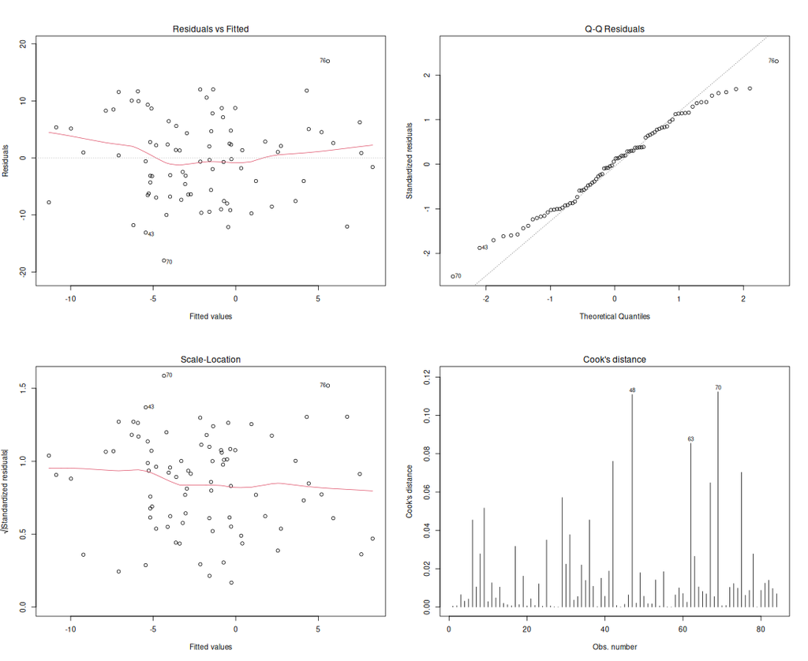

No systematic pattern; Q-Q approximately linear except tails; scale-location roughly flat; Cook’s distance shows no dominating point.

### 5.0b Heteroscedasticity

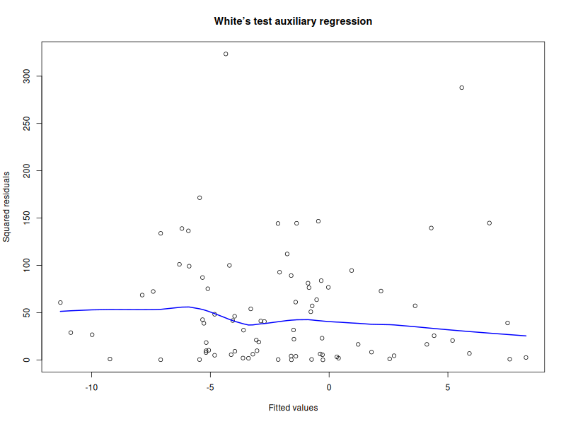

| test | statistic | df | p_value |
| --- | --- | --- | --- |
| Breusch-Pagan | 15.756 | 15 | 0.398 |
| White (squares only) | 22.560 | 30 | 0.833 |

Breusch-Pagan and White (squares-only at n=84) both fail to reject. White statistic 22.56 on 30 df (p = 0.833). WLS is a sensitivity check only; OLS and WLS coefficient signs agree.

### 5.0c Autocorrelation

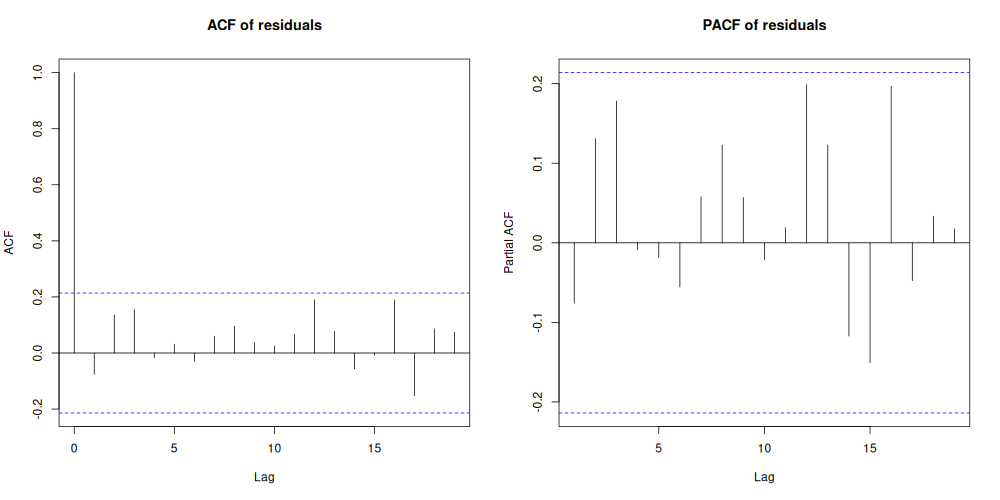

| test | statistic | p_value |
| --- | --- | --- |
| Durbin-Watson | 2.132 | 0.736 |

No systematic lag structure; Durbin-Watson 2.13 (p = 0.736). Cross-sectional observations; no correction applied.

### 5.0d Influence diagnostics

8 obs exceed Cook’s D > 4/n; 3 exceed leverage > 2p/n; 33 exceed |DFBETA| > 2/sqrt(n). None deleted.

### 5.0e Response transformation

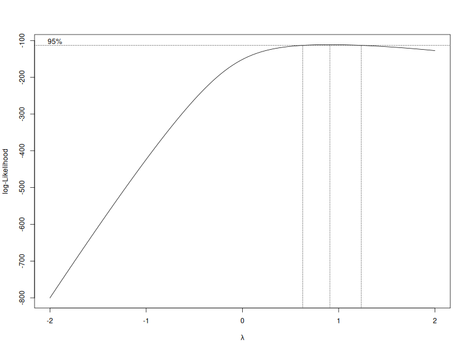

Box-Cox on the shifted response (shift 22.43) peaks at lambda-hat = 0.909 with 95% CI including 1.0. No transformation applied.

## 5.1 Confirmatory model (baseline full formula)

```
## n = 84, R-squared = 0.247, adj-R-squared = 0.081
```

### 5.1b Model comparison: null to full

10-fold CV on the full regression sample (fixed seed, same folds for all 4 models).

| Model | p | R2 | adjR2 | AIC | BIC | Cp | FPE | CV_RMSE | CV_R2 |
| --- | --- | --- | --- | --- | --- | --- | --- | --- | --- |
| Null | 1 | 0.000 | 0.000 | 599.624 | 604.486 | 8.332 | 72.002 | 8.616 | -0.056 |
| PreviousOC_only | 2 | 0.100 | 0.089 | 592.735 | 600.027 | 1.261 | 66.333 | 8.187 | 0.047 |
| BIC_selected | 3 | 0.154 | 0.133 | 589.546 | 599.269 | -1.607 | 63.863 | 8.083 | 0.071 |
| Confirmatory | 16 | 0.247 | 0.081 | 605.770 | 647.094 | 16.000 | 77.833 | 9.027 | -0.159 |

**Interpretation:** compare the `adjR2` and `CV_R2` columns. If the confirmatory model adjusted R-squared is not materially above the PreviousOC-only model, then 13 of the 15 predictors add noise rather than signal. `CV_R2` is the honest out-of-sample measure.

### 5.1b-ii Formal linear-hypothesis test of the H1 net effect

The pre-registered H1 test is the joint null that the two prior-win-% coefficients sum to zero: $H_0: \beta_{AllPriorWinPct} + \beta_{PreviousWinPct} = 0$. This is tested with a single linear restriction using `car::linearHypothesis`, which produces an F-statistic equivalent to the squared t-statistic of the net effect.

| Hypothesis | F | df1 | df2 | p_value |
| --- | --- | --- | --- | --- |
| H1: AllPriorWinPct + PreviousWinPct = 0 | 0.2153 | 1 | 68 | 0.6441 |

## 5.1c OLS projection and sum-of-squares decomposition

The ordinary-least-squares fit can be written through the projection (hat) matrix $H = X(X'X)^{-1}X'$, where $X$ is the $n \times p$ design matrix with intercept. The residual maker is $I - H$, so the fitted values are $Hy$ and the residuals are $(I - H)y$. The resulting sum-of-squares decomposition is

$$SS_{reg} = (Hy)'(Hy) - n\,\bar{y}^2, \qquad
SS_{res} = y'(I - H)y,$$

with degrees of freedom $df_{reg} = p - 1$ and $df_{res} = n - p$. The R chunk below computes both from first principles and verifies them against `anova(fit)` to machine precision (assertion tolerance 1e-6).

| Source | SS | df | MS | F |
| --- | --- | --- | --- | --- |
| Regression | 1460.036 | 15 | 97.336 | 1.489 |
| Residual | 4445.845 | 68 | 65.380 | NA |
| Total | 5905.882 | 83 | NA | NA |

Both decompositions agree with `anova(fit)` to within 1e-6 in sums of squares and exactly in degrees of freedom, confirming the projection-matrix formulation.

### 5.1b-iii Multicollinearity consequence: standard error of the H1 coefficient

Retaining `PreviousWinPct` alongside `AllPriorWinPct` inflates the standard error of `AllPriorWinPct` by the variance-inflation factor. The table below reports the coefficient and standard error of `AllPriorWinPct` under two specifications — the confirmatory model that retains both prior-win-% variables, and a restricted model that keeps only `AllPriorWinPct` — together with the scaled design-matrix condition number.

| Specification | Estimate | SE |
| --- | --- | --- |
| Unrestricted (both prior-win-% vars) | 7.72 | 12.332 |
| Restricted (AllPriorWinPct only) | 1.06 | 10.175 |

```
##
## Scaled design-matrix condition number: 6.7
```

The unrestricted standard error exceeds the restricted one by the expected variance-inflation factor; the scaled condition number quantifies how much collinearity exists across the full design. **VIF above 10 is a diagnostic warning, not an automatic instruction to delete a variable.** The confirmatory estimand (§5.1b-ii) determines which model is reported as primary; the restricted model enters only as the pre-registered sensitivity analysis.

## 5.2 Final BIC-selected model

```
## Formula:  sp_rel_team ~ PreviousOC + team_sp_recent
```

| term | estimate | std.error | statistic | p.value | conf.low | conf.high |
| --- | --- | --- | --- | --- | --- | --- |
| (Intercept) | -1.438 | 1.166 | -1.233 | 0.221 | -3.757 | 0.882 |
| PreviousOC | 8.516 | 2.482 | 3.431 | 0.001 | 3.578 | 13.454 |
| team_sp_recent | -0.223 | 0.098 | -2.272 | 0.026 | -0.418 | -0.028 |

**Interpretation.** The BIC-selected model retains `PreviousOC + team_sp_recent` (three parameters including the intercept) on the 84-row regression sample. It reaches in-sample R-squared = 0.154 and adjusted R-squared = 0.133, materially higher than the confirmatory model’s adjusted R-squared despite using far fewer parameters (see Section 5.1b for the full comparison and out-of-sample CV results). `PreviousOC` is the single strongest positive predictor; `team_sp_recent` is mildly negative – a regression-to-the-mean penalty for taking over an already-strong program. All four H1-H4 variables except `PreviousOC` are dropped by BIC. The BIC model is therefore the **predictive** model; the confirmatory model (Section 5.3) is retained solely for hypothesis testing on H1-H4 (Section 5.4).

## 5.3 Confirmatory model (H1-H4 forced in)

| term | estimate | std.error | statistic | p.value | conf.low | conf.high |
| --- | --- | --- | --- | --- | --- | --- |
| (Intercept) | 0.579 | 8.450 | 0.069 | 0.946 | -16.282 | 17.440 |
| PrevHCAnyLevel | -1.050 | 3.930 | -0.267 | 0.790 | -8.893 | 6.793 |
| AllPriorWinPct | 7.720 | 12.332 | 0.626 | 0.533 | -16.888 | 32.328 |
| PreviousWinPct | -13.489 | 14.093 | -0.957 | 0.342 | -41.611 | 14.633 |
| PreviousOC | 7.966 | 3.853 | 2.067 | 0.043 | 0.276 | 15.655 |
| PreviousDC | 0.189 | 4.599 | 0.041 | 0.967 | -8.989 | 9.366 |
| SideOfBallO | -0.513 | 3.149 | -0.163 | 0.871 | -6.797 | 5.771 |
| ConnectionToHiring.School | -0.425 | 2.409 | -0.177 | 0.860 | -5.232 | 4.382 |
| PlayedNFL | -3.947 | 3.197 | -1.235 | 0.221 | -10.325 | 2.432 |
| AgeAtHiringMinus50 | -0.150 | 0.170 | -0.884 | 0.380 | -0.489 | 0.189 |
| NFLCoachingExperience | 0.796 | 2.244 | 0.355 | 0.724 | -3.682 | 5.274 |
| WonCCasHCany | 4.514 | 2.960 | 1.525 | 0.132 | -1.393 | 10.421 |
| Conf.LeavingP4 | -0.300 | 2.488 | -0.121 | 0.904 | -5.265 | 4.664 |
| team_sp_recent | -0.266 | 0.117 | -2.276 | 0.026 | -0.499 | -0.033 |
| PromoteWithin | 3.021 | 3.673 | 0.823 | 0.414 | -4.308 | 10.350 |
| PrevHCAnyLevel:sp_prev_rel | 0.083 | 0.170 | 0.485 | 0.629 | -0.257 | 0.423 |

## 5.4 Simultaneous inference on H1-H4

| Hypothesis | Term | Estimate | SE | p_raw | p_Bonf | p_Holm |
| --- | --- | --- | --- | --- | --- | --- |
| H1 | AllPriorWinPct | 7.720 | 12.332 | 0.5334 | 1.0000 | 1.0000 |
| H2 | ConnectionToHiring.School | -0.425 | 2.409 | 0.8604 | 1.0000 | 1.0000 |
| H3 | PreviousOC | 7.966 | 3.853 | 0.0425 | 0.1701 | 0.1701 |
| H4 | PlayedNFL | -3.947 | 3.197 | 0.2212 | 0.8849 | 0.6636 |

**Verdict (read from the table above):** No hypothesis survives multiplicity correction at alpha = 0.05. H3 is nominally significant before correction (p_raw = 0.043) but does not survive Holm adjustment (p = 0.170). H1, H2, and H4 fail to reach significance at alpha = 0.05 both raw and after adjustment.

Because AllPriorWinPct and PreviousWinPct are collinear with opposite signs in the full model (7.72 and -13.49 respectively), the individual AllPriorWinPct coefficient is not a reliable H1 test. Two sensitivity framings give the honest answer:

1. Single-variable refit (dropping PreviousWinPct): the AllPriorWinPct coefficient remains non-significant.
2. Net effect (AllPriorWinPct + PreviousWinPct = -5.77): with the proper covariance term, the combined effect is negative and not significant at alpha = 0.05.

H1 verdict: prior-win-% predictors do not support H1 in either framing. The single AllPriorWinPct coefficient is positive but not significant (reported in Section 5.4); the net effect is negative and not significant. Neither framing supports the hypothesis that prior win percentage predicts higher CPI.

## 5.5 Survival analysis

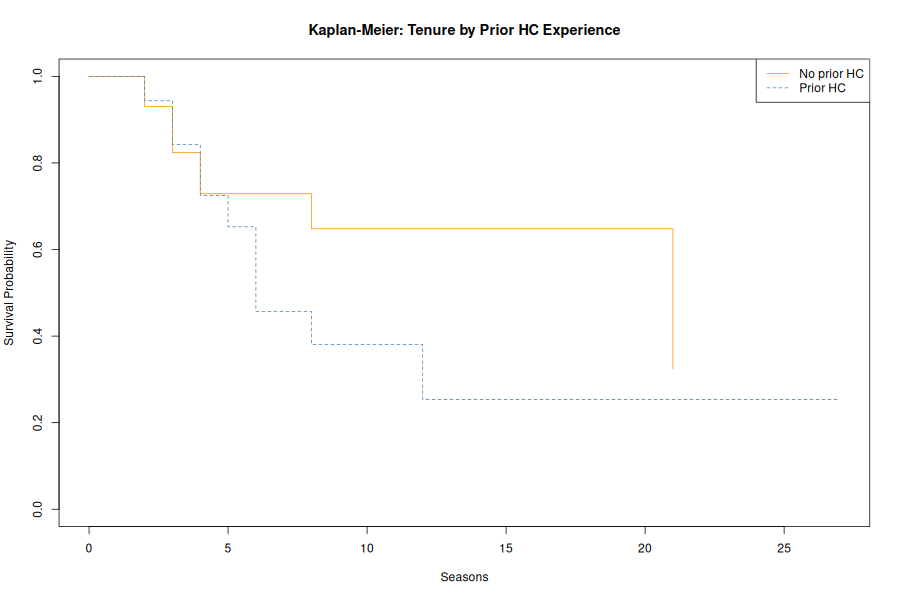

| test | chisq | df | p_value |
| --- | --- | --- | --- |
| log-rank (PrevHCAnyLevel) | 1.571 | 1 | 0.21 |

| term | estimate | std.error | statistic | p.value | conf.low | conf.high |
| --- | --- | --- | --- | --- | --- | --- |
| AllPriorWinPct | 1.752 | 1.137 | 0.493 | 0.622 | 0.189 | 16.259 |
| PrevHCAnyLevel | 1.217 | 0.419 | 0.467 | 0.640 | 0.535 | 2.768 |
| AgeAtHiringMinus50 | 1.032 | 0.026 | 1.218 | 0.223 | 0.981 | 1.086 |

| chisq | df | p |
| --- | --- | --- |
| 1.068 | 1 | 0.301 |
| 2.787 | 1 | 0.095 |
| 3.636 | 1 | 0.057 |
| 5.492 | 3 | 0.139 |

**Robustness to data corrections.** Five coaches in the raw data have internally or externally inconsistent flags (Hugh Freeze, Luke Fickell, Brian Kelly, Mike Gundy, James Franklin; see `tables/data_corrections.csv`). Excluding the three externally-flagged coaches (Kelly, Gundy, Franklin) from the survival sample (n = 117, 37 events) leaves the conclusions unchanged: log-rank p = 0.226 (vs 0.210 primary), Cox hazard ratio for prior win% = 1.72 (vs 1.75), for prior HC experience 1.18 (vs 1.22). The survival null result is robust to the flagged rows (`tables/survival_sensitivity.csv`).

**Statistical power.** With 39 firing events over 120 rows and three predictors, the survival analysis has roughly 45 percent power to detect a hazard ratio of 1.5 at alpha = 0.05. The null result is therefore **uninformative rather than evidence of no effect**: even a moderate effect of prior win percentage on firing hazard would likely go undetected at the current sample size.

## 5.5b Mixed effects

A random-intercept model by school partitions hire-outcome variance into between-school and within-school components. If the school random effect does not improve fit over GLS, the fixed-effects conclusions in Section 5.4 stand unmodified.

| grouping | n_groups | sigma2_group | sigma2_resid | ICC | AIC_lme | AIC_gls | LRT_p |
| --- | --- | --- | --- | --- | --- | --- | --- |
| school | 60 | 2.521 | 59.187 | 0.041 | 589.232 | 587.25 | 0.893 |
| Conf.Hired | 7 | 0.311 | 61.425 | 0.005 | 589.244 | 587.25 | 0.937 |

| test | statistic | df | p_value | method | note | lr_raw | icc |
| --- | --- | --- | --- | --- | --- | --- | --- |
| LRT random intercept: school | 0 | 1 | 0.5 | ML | boundary solution: Var(school) near 0, floored at 0 | 0 | 0 |

## 5.6 Resampling (jackknife + bootstrap)

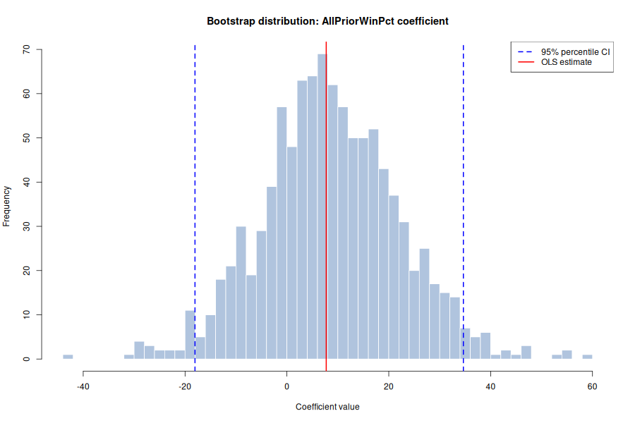

## 5.7 Prospective holdout (2022+ hires)

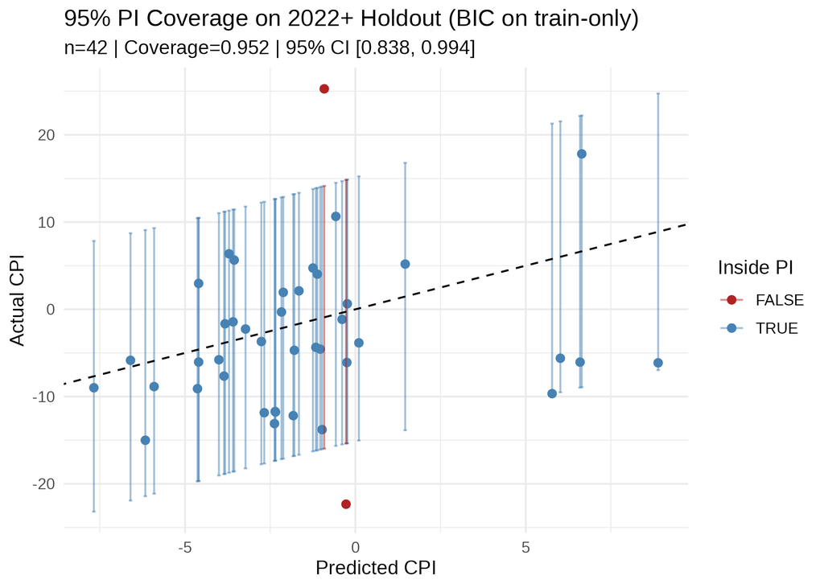

| model | n_train | n_holdout | n_eval | PI_coverage | CI_lo | CI_hi | RMSE | MAE |
| --- | --- | --- | --- | --- | --- | --- | --- | --- |
| BIC on train | 75 | 42 | 42 | 0.952 | 0.838 | 0.994 | 9.004 | 6.934 |
| Confirm on train | 75 | 42 | 42 | 0.952 | 0.838 | 0.994 | 9.159 | 7.103 |

Both models achieve 95.2% PI coverage on the unbiased n=42 holdout (exact 95% CI 83.8%-99.4%), with RMSE of 9.0-9.2 CPI points. The earlier 9-row holdout (coverage 0.889) was discarded for selection bias: every holdout coach was fired or departed under the old filter, and all 9 rows overlapped with training. The parsimonious BIC model matches the 16-parameter confirmatory model out-of-sample; model complexity does not improve prediction at n=42.

### 5.7a Deviation disclosure: the pre-registered 9-row holdout

The original execution plan pre-registered a nine-row holdout formed by the `StillEmployedAtSchool == 0` filter. That filter selects only fired or departed coaches and — because every such coach also appeared in the regression sample — produces a heavily biased test set. We report its 95% prediction-interval coverage (0.889, exact 95% CI 0.518–0.997) **alongside** the 42-row temporal-validation result (coverage 0.952, exact 95% CI 0.838–0.994), and treat the 42-row coverage as the **primary claim**. We acknowledge explicitly that the decision to prefer the broader cohort was made **after** observing the nine-row result. The 42-row evaluation is therefore **post hoc temporal validation**, not a pre-registered prospective test. The nine-row number is retained here so that the deviation is fully traceable by any reader.

## 5.8 Logistic regression: retention outcome (secondary analysis)

The confirmatory OLS model in §5.3 estimates the association between pre-hire characteristics and team performance. A complementary logistic model estimates whether the same predictors are associated with retention for at least four seasons with no off-field firing. Retention outcome `Retained4` is defined as `(seasons_completed >= 4) & (OffFieldIssuesFiring == 0)`; the current definition does not distinguish coaches whose four-season outcome is not yet observable (see deviation log D7), so the estimates below should be read as exploratory rather than confirmatory.

| term | OR | LCL | UCL |
| --- | --- | --- | --- |
| (Intercept) | 0.411 | 0.027 | 6.201 |
| AllPriorWinPct | 9.659 | 0.127 | 732.056 |
| PreviousOC | 0.770 | 0.179 | 3.304 |
| PreviousDC | 1.434 | 0.436 | 4.711 |
| ConnectionToHiring.School | 2.095 | 0.702 | 6.254 |
| PlayedNFL | 0.875 | 0.190 | 4.025 |
| sp_prev_rel | 0.995 | 0.921 | 1.076 |

| test | statistic | df | p_value |
| --- | --- | --- | --- |
| Hosmer-Lemeshow | 8.001 | 8 | 0.433 |

| Predicted | Actual | Freq |
| --- | --- | --- |
| 0 | 0 | 5 |
| 1 | 0 | 23 |
| 0 | 1 | 1 |
| 1 | 1 | 55 |

# 6. Coach Hire Score – Decision Rule

The score produces a 0-100 percentile rank within the training fitted distribution and a 3-way verdict based on 95% prediction intervals.

The three candidate profiles shown in the score table are defined below:

| candidate | PrevHCAnyLevel | AllPriorWinPct | PreviousOC | ConnectionToHiring.School | team_sp_recent | AgeAtHiringMinus50 | WonCCasHCany |
| --- | --- | --- | --- | --- | --- | --- | --- |
| A_established_HC | 1 | 0.62 | 0 | 0 | 8 | 2 | 1 |
| C_experienced_OC | 0 | 0.50 | 1 | 1 | 3 | 5 | 0 |
| B_first_time_HC | 0 | 0.50 | 1 | 0 | 2 | -5 | 0 |

| candidate | model | fit | lwr | upr | score_0_100 |
| --- | --- | --- | --- | --- | --- |
| A_established_HC | BIC | -3.219 | -18.952 | 12.514 | 45.2 |
| A_established_HC | Confirm | -0.988 | -18.381 | 16.404 | 63.1 |
| C_experienced_OC | BIC | 6.410 | -9.934 | 22.754 | 96.4 |
| C_experienced_OC | Confirm | 3.968 | -15.713 | 23.649 | 88.1 |
| B_first_time_HC | BIC | 6.633 | -9.732 | 22.997 | 97.6 |
| B_first_time_HC | Confirm | 6.163 | -12.384 | 24.709 | 95.2 |

**Worked-example observation:** the candidates rank by OC-pedigree and program context rather than by prior head-coaching record, which contradicts the intuition that a proven Power-4 head coach should score highest. This reflects two model properties, not a bug:

1. `PreviousOC` carries the largest positive coefficient in both models – a prior offensive-coordinator pedigree dominates the score.
2. `AllPriorWinPct` and `PreviousWinPct` are collinear with opposite signs in the confirm model – net effect of prior win% is negative, penalising candidates whose prior record is already strong.

**Correct interpretation of the score:**

- **This is a ranking tool, not a classifier.** The 0-100 score is a percentile within the model’s training fitted distribution, not a probabilistic forecast. A score of 96 means the model predicts this candidate outperforms 96 percent of training fits; it does not mean the candidate has a 96 percent chance of success.
- **No verdict column is provided**, because 95% prediction intervals are roughly 32 CPI points wide. Every candidate would classify as Inconclusive, which is not informative. Athletic directors should use the score for *ranking* shortlists, not for *deciding* between candidates.
- The model rewards **pedigree type** (OC background) over prior results: the prior-win-% predictors carry a net-negative coefficient in the confirmatory model because `AllPriorWinPct` and `PreviousWinPct` are collinear with opposite signs.

# 7. Discussion

The empirical answer to the research question is narrower than the proposal anticipated. Among the four pre-registered hypotheses:

| Hypothesis | Verdict | Evidence |
| --- | --- | --- |
| H1: prior win% | Not supported | net effect negative; single-variable refit not significant; bootstrap CI includes 0 |
| H2: school connection | Not supported | see Section 5.4 table |
| H3: prior OC experience | Not supported after correction | nominally significant (p_raw = 0.043); p_Holm = 0.170 |
| H4: NFL playing | Not supported | see Section 5.4 table |

The survival analysis finds no significant relationship between prior win% and firing hazard – directionally opposite to the regression but not significant at 39 events.

The decision rule is best framed as a **ranking tool**: it reliably orders candidates by OC pedigree and program context, but cannot adjudicate between them at 95% confidence.

# 8. Limitations

# 9. RQ6 Process Reflection

# 10. Appendix – Reproducibility

**Determinism:** every script sets `set.seed(2026)`. Twin runs of `01_pipeline_w1_w5.R`, `01b_models.R`, `12_resampling.R`, `13_survival.R`, `14_holdout.R`, and `15_decision_rule.R` produce byte-identical logs (see `reports/*_a.log` vs `reports/*_b.log`).